# Feature Engineering and Selection

Max Gold

2026-10

# Libraries

```r
library(dplyr)
library(tidyr)
library(ggplot2)
library(randomForest)
library(lubridate)
library(corrplot)
library(readr)
library(Boruta)
```

# Feature Creation

We will use the full season results from the 2014/15 English Premier League season to the 2024/25 season as our training data, then use the 2025/26 season as testing data, and then finally retraining our model with all the available information to forecast the results of the 2026/27 season. We have combined the historical results, as well as the fixtures of the 2026/27 season but not the goal or outcome results as they have not occurred yet, into one combined dataset which includes:

- Date
- DayOfWeek
- HomeTeam
- AwayTeam
- HomeGoals
- AwayGoals
- Result
- SeasonStart
- Season

We cannot include the time of day as this is only present in 2014/15 to 2018/19 seasons, but the date and day of the week should provide enough temporal information.

Subsequently, we assumed that recent information is much more relevant to predicting future matches than historical data from previous seasons, as a team’s performance changes considerably within a season let alone over multiple seasons. Hence, we will use a combination of expanding window and rolling window data as covariates, varying the size of the rolling window which we will denote as $k$.

We will introduce some rolling window information as numerical or categorical features, for example a team at any given point will have a value associated with the number of goals scored in the last $k$ matches, and this value will be updated after every match a team plays.

Here is a list of lagged rolling window or one-step-behind features we will be creating to analyse in the Feature Selection section:

- Home_GS, the home team’s average goals scored
- Home_GC, the home team’s average goals conceded
- Home_Points, the home team’s average points per match
- Home_Wins, the home team’s number of wins
- Home_Home_GS, the home team’s average goals scored in home matches
- Home_Home_GC, the home team’s average goals conceded in home matches

Likewise, the same covariates but with Away yield the away team’s information.

We also look at intra-season data, such as:

- Home_Position before the match
- Home_Current_Points during the season
- Home_GD current season goal difference
- Home_History, number of previous matches available to lag

Likewise, the same covariates under Away are for the away teams.

## Historical Features

We can start creating our historical features by creating `create_features_by_date`. This sorts our data chronologically and initialises the days of the week as factors, the teams who have previously played in the Premier League per season, and whether the team is playing home or away. We then extract all matches taking place on specific dates, and each date is given features before any results from that day’s matches are added to our history state. This acts as a buffer between historical performance tracking and creating the features, and stops possible data leakage.

Next, we find when the season changes, and we need to create a “previous season” summary which involves previous year league positions and sets them as the new starting positions, as well as rolling goal information. Then, we use `create_today_features_fast` to calculate the features of the specific day’s matches before updating the historical state. Finally, we combine all the features into a dataframe and append them to the original dataset, creating our enlarged but self-made goals data.

```r
create_features_by_date <- function(data, k, day_levels = NULL) {

  data <- data |>
    arrange(Date)

  if (nrow(data) == 0) {
    return(data)
  }

  if (is.null(day_levels)) {
    day_levels <- sort(unique(
      as.character(data$DayOfWeek[!is.na(data$DayOfWeek)])
    ))
  }

  # Identify teams in each season
  season_teams <- lapply(
    split(data, as.character(data$SeasonStart)),
    function(x) {
      unique(c(
        as.character(x$HomeTeam),
        as.character(x$AwayTeam)
      ))
    }
  )

  # Initialise all team histories and standings
  teams <- unique(c(
    as.character(data$HomeTeam),
    as.character(data$AwayTeam)
  ))

  state <- initialise_state(teams)

  dates <- sort(unique(data$Date))

  output <- vector("list", length(dates))

  # Process matches by date
  for (d in seq_along(dates)) {

    current_date <- dates[d]

    today <- data |>
      filter(Date == current_date)

    season <- as.character(today$SeasonStart[1])

    # Handle season changes
    if (
      is.null(state$current_season) ||
      state$current_season != season
    ) {

      state <- start_season_fast(
        state,
        season,
        season_teams[[season]]
      )
    }

    # Calculate every fixture's features BEFORE updating results
    today_features <- create_today_features_fast(
      today = today,
      state = state,
      k = k,
      day_levels = day_levels
    )

    output[[d]] <- today_features

    # Only update histories using completed matches
    completed <- which(
      !is.na(today$HomeGoals) &
      !is.na(today$AwayGoals)
    )

    for (j in completed) {

      state <- update_state_fast(
        state,
        as.character(today$HomeTeam[j]),
        as.character(today$AwayTeam[j]),
        today$HomeGoals[j],
        today$AwayGoals[j]
      )
    }
  }

  bind_rows(output)
}
```

## History Storage

The `initialise_state` function stores the history of each club and sets them all to zero before being passed and assigned into `create_features_by_date`. This allows for each $k$th state to have essential goal data stored to be applied to each match for each team and extracted for rolling feature performance.

```r
initialise_state <- function(teams) {

  empty_history <- function() {
    list(
      GF = numeric(),
      GA = numeric(),
      Points = numeric(),
      Venue = character()
    )
  }

  list(
    history = setNames(
      lapply(teams, function(x) empty_history()),
      teams
    ),

    standings = matrix(
      0,
      nrow = length(teams),
      ncol = 3,
      dimnames = list(
        teams,
        c("Points", "GF", "GA")
      )
    ),

    current_season = NULL,
    current_teams = NULL,
    previous_positions = NULL,
    starting_positions = NULL
  )
}
```

## Recent Match Information

This function finds the information for the $k$-th recent matches, so points scored in the last $k$ matches or games won in the last $k$ matches at home. It selects the relevant matches, creates the rolling features as floating point and then returns them to the historical performance state.

```r
get_recent_stats_fast <- function(history, k, venue = NULL) {

  if (is.null(venue)) {
    indices <- seq_along(history$GF)
  } else {
    indices <- which(history$Venue == venue)
  }

  indices <- tail(indices, k)

  if (length(indices) == 0) {
    return(list(
      GoalsScored = 0,
      GoalsConceded = 0,
      Points = 0,
      Wins = 0,
      Draws = 0,
      Losses = 0,
      Matches = 0
    ))
  }

  list(
    GoalsScored = mean(history$GF[indices]),
    GoalsConceded = mean(history$GA[indices]),
    Points = mean(history$Points[indices]),
    Wins = sum(history$Points[indices] == 3),
    Draws = sum(history$Points[indices] == 1),
    Losses = sum(history$Points[indices] == 0),
    Matches = length(indices)
  )
}
```

## Season Updates

```r
start_season_fast <- function(state, season, current_teams) {

  # Calculate previous season's final positions
  if (!is.null(state$current_season)) {

    previous_table <- data.frame(
      Team = state$current_teams,
      Points = state$standings[state$current_teams, "Points"],
      GF = state$standings[state$current_teams, "GF"],
      GA = state$standings[state$current_teams, "GA"]
    )

    previous_table$GD <-
      previous_table$GF - previous_table$GA

    previous_table <- previous_table[
      order(
        -previous_table$Points,
        -previous_table$GD,
        -previous_table$GF,
        previous_table$Team
      ),
    ]

    state$previous_positions <- setNames(
      seq_len(nrow(previous_table)),
      previous_table$Team
    )
  }

  state$current_season <- as.character(season)
  state$current_teams <- current_teams

  # Initialise previous-season positions
  state$starting_positions <- NULL

  if (!is.null(state$previous_positions)) {

    starting_positions <-
      state$previous_positions[current_teams]

    promoted <- is.na(starting_positions)

    # Give all promoted teams the same starting position
    if (any(promoted)) {

      starting_positions[promoted] <-
        max(state$previous_positions) + 1
    }

    state$starting_positions <- starting_positions
  }

  # Reset current-season standings
  state$standings[,] <- 0

  state
}
```

## Post-match State updates

After every match has taken place, we update the historical state with the match outcomes so that the points, goals scored, and history are set for the next match. It also updates the league standings so that the positions after every match are reflective of how many points each team has.

```r
update_state_fast <- function(state, home, away, hg, ag) {

  hp <- if (hg > ag) {
    3
  } else if (hg == ag) {
    1
  } else {
    0
  }

  ap <- if (ag > hg) {
    3
  } else if (ag == hg) {
    1
  } else {
    0
  }

  # Update home team's match history
  h <- state$history[[home]]

  h$GF <- c(h$GF, hg)
  h$GA <- c(h$GA, ag)
  h$Points <- c(h$Points, hp)
  h$Venue <- c(h$Venue, "Home")

  state$history[[home]] <- h

  # Update away team's match history
  a <- state$history[[away]]

  a$GF <- c(a$GF, ag)
  a$GA <- c(a$GA, hg)
  a$Points <- c(a$Points, ap)
  a$Venue <- c(a$Venue, "Away")

  state$history[[away]] <- a

  # Update league standings
  state$standings[home, "Points"] <-
    state$standings[home, "Points"] + hp

  state$standings[home, "GF"] <-
    state$standings[home, "GF"] + hg

  state$standings[home, "GA"] <-
    state$standings[home, "GA"] + ag

  state$standings[away, "Points"] <-
    state$standings[away, "Points"] + ap

  state$standings[away, "GF"] <-
    state$standings[away, "GF"] + ag

  state$standings[away, "GA"] <-
    state$standings[away, "GA"] + hg

  state
}
```

## League Positions

This function inspects the historical performance state and creates the ranking table for the set season at the given match.

```r
get_current_table_fast <- function(state) {

  teams <- state$current_teams

  table_now <- data.frame(
    Team = teams,

    Points = unname(
      state$standings[teams, "Points"]
    ),

    GF = unname(
      state$standings[teams, "GF"]
    ),

    GA = unname(
      state$standings[teams, "GA"]
    )
  )

  table_now$GD <- table_now$GF - table_now$GA

  if (!is.null(state$starting_positions)) {

    table_now$PreviousPosition <-
      unname(state$starting_positions[table_now$Team])

  } else {

    table_now$PreviousPosition <- NA_real_
  }

  table_now <- table_now[
    order(
      -table_now$Points,
      -table_now$GD,
      -table_now$GF,
      table_now$PreviousPosition,
      na.last = TRUE
    ),
  ]

  table_now$Position <- seq_len(nrow(table_now))

  table_now
}
```

## Day by Day Features

This function uses the historical performance state to generate the features for each day of matches in a season, using the number of recent matches, the date, and the day of the week. It calculates the day’s league table, along with the points, goal difference, and positions of each team playing. For each match, it generates the features both rolling lag and current season, which creates an overall match feature profile that it can attach to the dataset for each match.

```r
create_today_features_fast <- function(
    today,
    state,
    k,
    day_levels
) {

  # Calculate the league table once for today's fixtures
  table_now <- get_current_table_fast(state)

  positions <- setNames(
    table_now$Position,
    table_now$Team
  )

  points <- setNames(
    table_now$Points,
    table_now$Team
  )

  goal_difference <- setNames(
    table_now$GD,
    table_now$Team
  )

  # Generate features for each fixture
  features <- lapply(seq_len(nrow(today)), function(i) {

    home <- as.character(today$HomeTeam[i])
    away <- as.character(today$AwayTeam[i])

    # Overall recent performance
    home_stats <- get_recent_stats_fast(
      state$history[[home]], k
    )

    away_stats <- get_recent_stats_fast(
      state$history[[away]], k
    )

    # Venue-specific recent performance
    home_venue_stats <- get_recent_stats_fast(
      state$history[[home]], k, venue = "Home"
    )

    away_venue_stats <- get_recent_stats_fast(
      state$history[[away]], k, venue = "Away"
    )

    data.frame(

      Date = today$Date[i],
      SeasonStart = today$SeasonStart[i],

      DayOfWeek = factor(
        as.character(today$DayOfWeek[i]),
        levels = day_levels
      ),

      HomeTeam = home,
      AwayTeam = away,

      # Overall recent performance
      Home_GS = home_stats$GoalsScored,
      Home_GC = home_stats$GoalsConceded,
      Home_Points = home_stats$Points,
      Home_Wins = home_stats$Wins,

      Away_GS = away_stats$GoalsScored,
      Away_GC = away_stats$GoalsConceded,
      Away_Points = away_stats$Points,
      Away_Wins = away_stats$Wins,

      # Venue-specific recent performance
      Home_Home_GS = home_venue_stats$GoalsScored,
      Home_Home_GC = home_venue_stats$GoalsConceded,

      Away_Away_GS = away_venue_stats$GoalsScored,
      Away_Away_GC = away_venue_stats$GoalsConceded,

      # League standings
      Home_Position = unname(positions[home]),
      Away_Position = unname(positions[away]),

      Home_Current_Points = unname(points[home]),
      Away_Current_Points = unname(points[away]),

      Home_GD = unname(goal_difference[home]),
      Away_GD = unname(goal_difference[away]),

      # Historical information
      Home_History = home_stats$Matches,
      Away_History = away_stats$Matches,

      # Response variables
      HomeGoals = today$HomeGoals[i],
      AwayGoals = today$AwayGoals[i]

    )
  })

  do.call(rbind, features)
}
```

## Creating the Features

We read the combined fixtures and results table gathered previously, adjoining the season start and season year:

```r
combined_data = read.csv("https://raw.githubusercontent.com/Mathildelaunay/Sprint-1/refs/heads/main/Max%20Gold/combined_data.csv")

combined_data <- combined_data |>
  mutate(
    Date = dmy(Date),
    DayOfWeek = weekdays(Date),
    SeasonStart = if_else(
      month(Date) >= 8,
      year(Date),
      year(Date) - 1
    ),

    Season = paste0(
      SeasonStart,
      "/",
      substr(SeasonStart + 1, 3, 4)
    )
  )
```

# Feature Selection

Now we must choose which of the features we have selected to include in our home and away random forest. We first split our combined match data into training, testing, and prediction data, and then extract the features that are present within the training period.

```r
features_5 = read.csv("https://raw.githubusercontent.com/Mathildelaunay/Sprint-1/refs/heads/main/Max%20Gold/features_5.csv")

training_data <- combined_data |>
  filter(SeasonStart >= 2014,
         SeasonStart <= 2024,
         !is.na(HomeGoals),
         !is.na(AwayGoals)) |>
  mutate(
    DayOfWeek = factor(DayOfWeek))

testing_data <- combined_data |>
  filter(SeasonStart == 2025)

prediction_data <- combined_data |>
  filter(SeasonStart == 2026)

training_features <- features_5 |>
  filter(
    SeasonStart >= 2014,
    SeasonStart <= 2024,
    !is.na(HomeGoals),
    !is.na(AwayGoals)
  ) |>
  mutate(
    DayOfWeek = factor(DayOfWeek)

  )
```

Here we select our feature information using $k=5$ and converting it into purely numeric data. We can then create a correlation matrix to investigate which of our features are highly correlated and can possibly be removed.

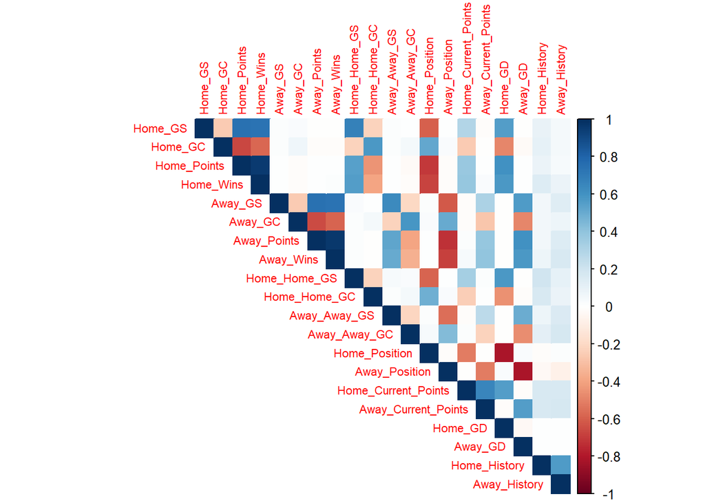

```r
model_data <- features_5 |>
  filter(
    SeasonStart >= 2014,
    SeasonStart <= 2024,
    !is.na(HomeGoals),
    !is.na(AwayGoals)
  ) |>
  select(
    -Date,
    -SeasonStart,
    -HomeTeam,
    -AwayTeam,
    -AwayGoals
  )

numeric_data <- model_data |>
  select(where(is.numeric)) |>
  select(-HomeGoals)

correlation_matrix <- cor(
  numeric_data,
  use = "pairwise.complete.obs"
)

corrplot::corrplot(
  correlation_matrix,
  method = "color",
  type = "upper",
  tl.cex = 0.7
)
```

We can see that the features `Home_Wins` and `Home_Points` are highly correlated, since points contain wins as a high proportion of their creation i.e. $\#\text{points} = 3 \times \#\text{wins} + \#\text{draws}$. Likewise for “Away”, we can remove the wins feature as it adds no predictive power to the model.

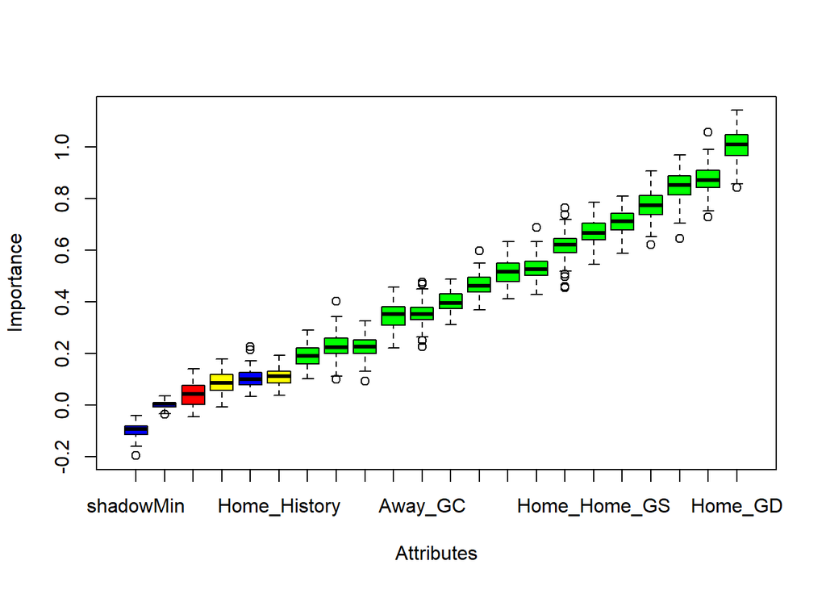

```r
home_data <- training_features |>
  select(
    -Date,
    -SeasonStart,
    -HomeTeam,
    -AwayTeam,
    -AwayGoals,
    -Home_Wins,
    -Away_Wins
  )

away_data <- training_features |>
  select(
    -Date,
    -SeasonStart,
    -HomeTeam,
    -AwayTeam,
    -HomeGoals,
    -Home_Wins,
    -Away_Wins
  )

boruta_home <- Boruta(
  HomeGoals ~ .,
  data = home_data,
  doTrace = 0,
  maxRuns = 100
)

plot(boruta_home)
```

```r
boruta_home
```

```
## Boruta performed 99 iterations in 1.701 mins.
##  16 attributes confirmed important: Away_Away_GC, Away_Away_GS,
## Away_Current_Points, Away_GC, Away_GD and 11 more;
##  1 attributes confirmed unimportant: DayOfWeek;
##  2 tentative attributes left: Away_History, Home_History;
```

```r
selected_features <- getSelectedAttributes(
  boruta_home,
  withTentative = FALSE
)

selected_features
```

```
##  [1] "Home_GS"             "Home_GC"             "Home_Points"
##  [4] "Away_GS"             "Away_GC"             "Away_Points"
##  [7] "Home_Home_GS"        "Home_Home_GC"        "Away_Away_GS"
## [10] "Away_Away_GC"        "Home_Position"       "Away_Position"
## [13] "Home_Current_Points" "Away_Current_Points" "Home_GD"
## [16] "Away_GD"
```

```r
rf_home_initial <- randomForest(
  HomeGoals ~ .,
  data = home_data,
  ntree = 1000,
  importance = TRUE
)

importance(rf_home_initial)
```

```
##                       %IncMSE IncNodePurity
## DayOfWeek            1.095194     316.70543
## Home_GS             20.233257     367.78591
## Home_GC             11.955929     308.92559
## Home_Points         26.595083     324.24061
## Away_GS             19.668219     350.01005
## Away_GC             16.243564     317.89484
## Away_Points         22.546938     307.05150
## Home_Home_GS        29.593141     425.24350
## Home_Home_GC        13.357521     336.91263
## Away_Away_GS        14.679914     345.83538
## Away_Away_GC         9.432681     343.91950
## Home_Position       31.510092     485.88335
## Away_Position       31.762617     402.76896
## Home_Current_Points 30.978035     488.10135
## Away_Current_Points 31.046341     454.35052
## Home_GD             39.152477     662.38026
## Away_GD             40.140138     491.56155
## Home_History         5.814693      16.60377
## Away_History         4.469900      14.26601
```

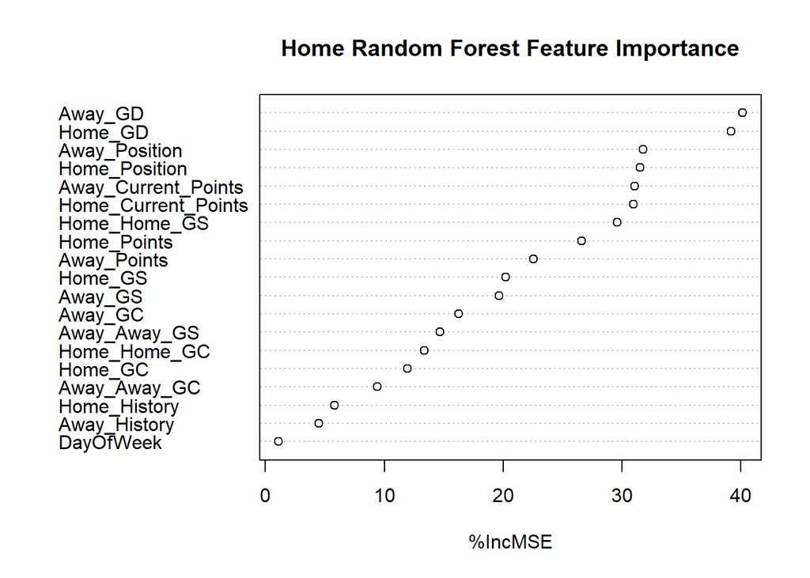

```r
varImpPlot(
  rf_home_initial,
  type = 1,
  main = "Home Random Forest Feature Importance"
)
```

```r
importance_scores <- importance(rf_home_initial, type = 1)
importance_sorted <- sort(importance_scores[, 1], decreasing = TRUE)
home_features <- names(importance_sorted)[1:10]
home_features
```

```
##  [1] "Away_GD"             "Home_GD"             "Away_Position"
##  [4] "Home_Position"       "Away_Current_Points" "Home_Current_Points"
##  [7] "Home_Home_GS"        "Home_Points"         "Away_Points"
## [10] "Home_GS"
```

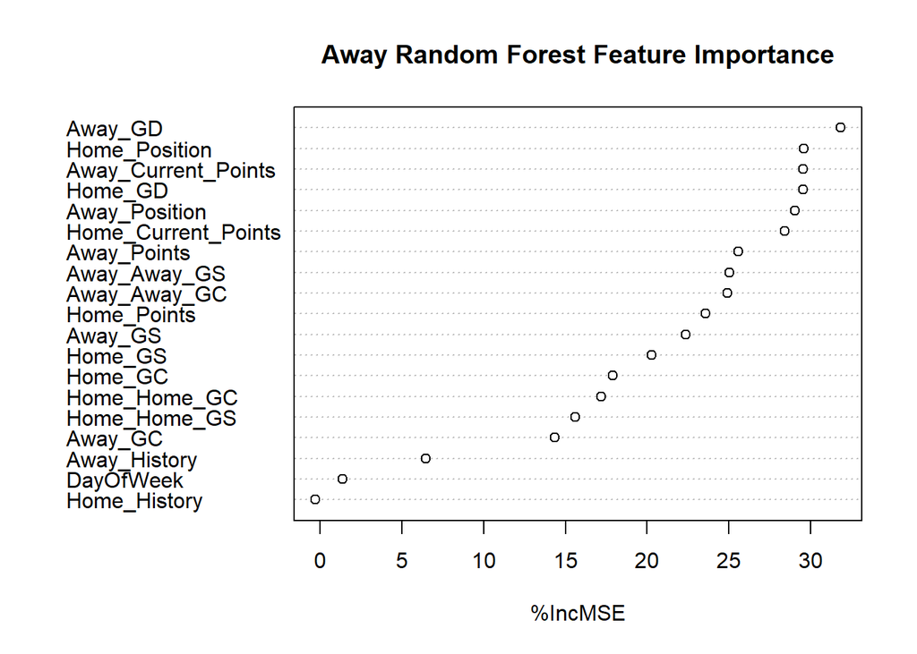

```r
rf_away_initial <- randomForest(
  AwayGoals ~ .,
  data = away_data,
  ntree = 1000,
  importance = TRUE
)

varImpPlot(rf_away_initial, type = 1, main="Away Random Forest Feature Importance")
```

```r
importance_scores_a <- importance(rf_away_initial, type = 1)
importance_sorted_a <- sort(importance_scores_a[, 1], decreasing = TRUE)
away_features <- names(importance_sorted_a)[1:10]
away_features
```

```
##  [1] "Away_GD"             "Home_Position"       "Away_Current_Points"
##  [4] "Home_GD"             "Away_Position"       "Home_Current_Points"
##  [7] "Away_Points"         "Away_Away_GS"        "Away_Away_GC"
## [10] "Home_Points"
```

Investigating the importance plots we can see that there are approximately 10 features on both forests that are highly explanative in `%incMSE` and thus we keep them for modelling.